# 마지막 실습

```python
import pandas as pd
import numpy as np
from matplotlib import rc
import matplotlib.pyplot as plt
import seaborn as sns
import matplotlib.font_manager as fm
import joblib
from sklearn.preprocessing import StandardScaler, MinMaxScaler, RobustScaler, MaxAbsScaler
#from sklearn.metrics import r2_score
from sklearn.metrics import confusion_matrix, accuracy_score
from sklearn.metrics import precision_score, recall_score
from sklearn.metrics import f1_score, roc_auc_score,roc_curve
from sklearn.metrics import classification_report
from sklearn.metrics import precision_recall_curve
from sklearn.model_selection import train_test_split
#from sklearn.metrics import mean_squared_error
from lightgbm import LGBMClassifier
from xgboost import XGBClassifier
from catboost import CatBoostClassifier
import warnings

plt.rcParams['axes.unicode_minus']=False
plt.rcParams['font.family']='NanumGothic'
%matplotlib inline
pd.set_option('display.max_columns', None)
warnings.filterwarnings('ignore')

from sklearn.preprocessing import Binarizer
```

```python
from category_encoders import TargetEncoder
```

```python
def precision_recall_curve_plot(y_test , pred_proba_c1):
    # threshold ndarray와 이 threshold에 따른 정밀도, 재현율 ndarray 추출.
    precisions, recalls, thresholds = precision_recall_curve( y_test, pred_proba_c1)

    # X축을 threshold값으로, Y축은 정밀도, 재현율 값으로 각각 Plot 수행. 정밀도는 점선으로 표시
    plt.figure(figsize=(8,6))
    threshold_boundary = thresholds.shape[0]
    plt.plot(thresholds, precisions[0:threshold_boundary], linestyle='--', label='precision')
    plt.plot(thresholds, recalls[0:threshold_boundary],label='recall')

    # threshold 값 X 축의 Scale을 0.1 단위로 변경
    start, end = plt.xlim()
    plt.xticks(np.round(np.arange(start, end, 0.1),2))

    # x축, y축 label과 legend, 그리고 grid 설정
    plt.xlabel('Threshold value'); plt.ylabel('Precision and Recall value')
    plt.legend(); plt.grid()
    plt.show()
```

```python
def get_clf_eval(y_test, pred=None, pred_proba=None):
    confusion = confusion_matrix( y_test, pred)
    accuracy = accuracy_score(y_test , pred)
    precision = precision_score(y_test , pred)
    recall = recall_score(y_test , pred)
    f1 = f1_score(y_test,pred)
    # ROC-AUC 추가
    roc_auc = roc_auc_score(y_test, pred_proba)
    print('오차 행렬')
    print(confusion)
    # ROC-AUC print 추가
    print('정확도: {0:.4f}, 정밀도: {1:.4f}, 재현율: {2:.4f},\
    F1: {3:.4f}, AUC:{4:.4f}'.format(accuracy, precision, recall, f1, roc_auc))
```

```python
user_loan_train = pd.read_csv("./사용데이터/user_loan_train.csv", encoding = 'cp949')
user_loan_target = pd.read_csv("./사용데이터/user_loan_target.csv", encoding = 'cp949')
cluster_info = pd.read_csv("./사용데이터/cluster_result.csv", encoding = 'cp949')
bank_cluster_info = pd.read_csv("./사용데이터/bank_cluster_result.csv", encoding = 'cp949')
print(1)

user_loan_train = pd.merge(user_loan_train,cluster_info, left_on = '상품번호', right_on = '상품번호', how = 'inner')
user_loan_target = pd.merge(user_loan_target,cluster_info, left_on = '상품번호', right_on = '상품번호', how = 'inner')
print(2)

user_loan_train = pd.merge(user_loan_train,bank_cluster_info, left_on = '금융사번호', right_on = '금융사번호', how = 'inner')
user_loan_target = pd.merge(user_loan_target,bank_cluster_info, left_on = '금융사번호', right_on = '금융사번호', how = 'inner')
print(3)
```

```
1
2
3
```

```python
user_loan_train.columns
```

```
Index(['월', '일', '생성일시', '신청서번호', '유저번호', '나이', '한도조회당시유저신용점수', '연소득', '근로형태',
       '고용형태', '주거소유형태', '대출희망금액', '대출목적', '개인회생자여부', '기대출수', '기대출금액', '금융사번호',
       '상품번호', '승인한도', '승인금리', '신청여부(타겟)', '상품군집', '은행군집'],
      dtype='object')
```

## 파생변수 추가

**추천상품 수 추가**

```python
count_df1 = user_loan_train[["신청서번호","월"]]
count_df2 = count_df1.groupby("신청서번호").count().reset_index()
count_df2.rename(columns = {"월": "추천상품수"}, inplace = True)
count_df2 = pd.merge(count_df1, count_df2, how = "left", left_on = "신청서번호", right_on = "신청서번호")
user_loan_train["추천상품수"]= count_df2["추천상품수"]
```

**최소금리여부 추가**

- 추천된 금리중 최소인가를 판단하는 라벨을 넣는다.

```python
ir_df = user_loan_train[["신청서번호","승인금리"]]
ir_min_df=pd.DataFrame(ir_df.groupby("신청서번호").min()).reset_index()
ir_min_df.rename(columns = {"승인금리":"승인금리최소"}, inplace = True)
ir_min_df = pd.merge(ir_df, ir_min_df, how = "left", left_on = "신청서번호", right_on = "신청서번호")
ir_min_df["최소금리여부"] = ir_min_df["승인금리"] == ir_min_df["승인금리최소"]
ir_min_df["최소금리여부"].replace({True:1, False :0}, inplace = True)
user_loan_train["최소금리여부"] = ir_min_df["최소금리여부"]
```

**추천 평균금리 추가**

```python
ir_mean_df = pd.DataFrame(ir_df.groupby("신청서번호").mean()).reset_index()
ir_mean_df.rename(columns = {"승인금리":"승인금리평균"}, inplace = True)
ir_mean_df = pd.merge(ir_df, ir_mean_df, how = "left", left_on = "신청서번호", right_on = "신청서번호")
user_loan_train["승인금리평균"]= ir_mean_df["승인금리평균"]
```

**최대한도 여부**

- 추천된 한도 중 최대였는가를 판단하는 라벨

```python
lm_df = user_loan_train[["신청서번호","승인한도"]]
lm_max_df=pd.DataFrame(lm_df.groupby("신청서번호").max()).reset_index()
lm_max_df.rename(columns = {"승인한도":"승인한도최대"}, inplace = True)
lm_max_df = pd.merge(lm_df, lm_max_df, how = "left", left_on = "신청서번호", right_on = "신청서번호")
lm_max_df["최대한도여부"] = lm_max_df["승인한도"] == lm_max_df["승인한도최대"]
lm_max_df["최대한도여부"].replace({True:1, False :0}, inplace = True)
user_loan_train["최대한도여부"] = lm_max_df["최대한도여부"]
```

**추천평균한도 추가**

```python
lm_mean_df = pd.DataFrame(lm_df.groupby("신청서번호").mean()).reset_index()
lm_mean_df.rename(columns = {"승인한도":"승인한도평균"}, inplace = True)
lm_mean_df = pd.merge(lm_df, lm_mean_df, how = "left", left_on = "신청서번호", right_on = "신청서번호")
user_loan_train["승인한도평균"] = lm_mean_df["승인한도평균"]
```

**left로 join 했기 때문에 user_loan_train과 데이터 순서가 같기 때문에 바로 넣어도 무방하다.**

## 예측 준비

```python
y_for_train = user_loan_train["신청여부(타겟)"]
```

```python
X_for_test = user_loan_train.drop(["생성일시","신청서번호", "유저번호","나이","금융사번호","상품번호","신청여부(타겟)"], axis = 1)
X_for_target = user_loan_target.drop(["생성일시","신청서번호", "유저번호","나이","금융사번호","상품번호","신청여부(타겟)"], axis = 1)
```

```python
tar_no = pd.DataFrame(user_loan_train[user_loan_train["신청여부(타겟)"]==0]["상품군집"].value_counts())
tar_yes = pd.DataFrame(user_loan_train[user_loan_train["신청여부(타겟)"]==1]["상품군집"].value_counts())
tar_all = pd.concat([tar_no,tar_yes], axis=1)
tar_all.columns = [["타겟0","타겟1"]]
```

```python
tar_all["총합"] = tar_all["타겟0"].values + tar_all["타겟1"].values
tar_all["1비율"] = tar_all["타겟1"].values/tar_all["총합"].values
    #tar_all["1비율"]*100
display(tar_all)
```

|  | 타겟0 | 타겟1 | 총합 | 1비율 |
| --- | --- | --- | --- | --- |
| 0 | 7239692 | 303581 | 7543273 | 0.040245 |
| 1 | 2468844 | 251003 | 2719847 | 0.092286 |
| 2 | 1139 | 127 | 1266 | 0.100316 |

### 상품군집 get_dummies (밑에 target_encoding 사용함)

**밑에 상품군집과 은행군집 target_encoding하는 방법도 적었다.**

```python
X_for_test = pd.get_dummies(data = X_for_test, columns = ["상품군집"])
X_for_test = pd.get_dummies(data = X_for_test, columns = ["은행군집"])
```

```python
X_for_target = pd.get_dummies(data = X_for_target, columns = ["상품군집"])
X_for_target = pd.get_dummies(data = X_for_target, columns = ['은행군집'])
```

```python
X_for_test
```

[output not shown]

## Target encoding

**나머지 category데이터들은 target_encoding**

```python
def target_encoder_app(cat, label, Df, Df2):
    i = 0
    l = len(cat)
    Df0 = pd.concat([Df,label], axis=1)
    for col in cat:
        encoder = TargetEncoder()
        encoder.fit(Df0[col], Df0["신청여부(타겟)"])
        Df[col] = encoder.transform(Df[col])
        Df2[col] = encoder.transform(Df2[col])
        i += 1
        print("{0}%만큼 완료".format(i*100/l))
    return Df, Df2
```

```python
cat = ["근로형태","고용형태","주거소유형태","대출목적"]
```

- 상품군집은 target encodeing이 안됨

```python
X_for_test, X_for_target = target_encoder_app(cat, y_for_train, X_for_test, X_for_target)
```

```
25.0%만큼 완료
50.0%만큼 완료
75.0%만큼 완료
100.0%만큼 완료
```

```python
X_for_test.head(4)
```

|  | 월 | 일 | 한도조회당시유저신용점수 | 연소득 | 근로형태 | 고용형태 | 주거소유형태 | 대출희망금액 | 대출목적 | 개인회생자여부 | 기대출수 | 기대출금액 | 승인한도 | 승인금리 | 상품군집 | 은행군집 | 추천상품수 | 최소금리여부 | 승인금리평균 | 최대한도여부 | 승인한도평균 |
| --- | --- | --- | --- | --- | --- | --- | --- | --- | --- | --- | --- | --- | --- | --- | --- | --- | --- | --- | --- | --- | --- |
| 0 | 4 | 20 | 670.0 | 50000000.0 | 0.118060 | 0.125329 | 0.054801 | 25000000.0 | 0.041517 | 0.0 | 3.0 | 76000000.0 | 3000000.0 | 14.5 | 0 | 1 | 2 | 1 | 17.200000 | 1 | 2.000000e+06 |
| 1 | 4 | 20 | 730.0 | 95000000.0 | 0.043153 | 0.045456 | 0.054801 | 40000000.0 | 0.041517 | 0.0 | 4.0 | 142000000.0 | 14000000.0 | 13.5 | 0 | 1 | 30 | 0 | 13.156667 | 0 | 2.170000e+07 |
| 2 | 4 | 20 | 740.0 | 50000000.0 | 0.127139 | 0.125329 | 0.054801 | 30000000.0 | 0.041517 | 0.0 | 3.0 | 37000000.0 | 9000000.0 | 13.5 | 0 | 1 | 11 | 0 | 14.036364 | 0 | 2.181818e+07 |
| 3 | 4 | 20 | 800.0 | 30000000.0 | 0.043153 | 0.045456 | 0.054801 | 8000000.0 | 0.055166 | 0.0 | 4.0 | 184000000.0 | 36000000.0 | 11.9 | 0 | 1 | 48 | 0 | 12.270833 | 0 | 2.704167e+07 |

**상품군집과 은행군집은 숫자여서 타겟인코더가 적용되지 않는다. 문자로 바꾸는 작업 필요**

```python
prod = [0,1,2]
bank = [0,1,2,3]
rep = 'abcde'
```

```python
for i in prod:
    X_for_test.replace({"상품군집":{i:rep[i]}}, inplace = True)
```

```python
for i in bank:
    X_for_test.replace({"은행군집":{i:rep[i]}}, inplace = True)
```

```python
cat2 = ["상품군집","은행군집"]
```

```python
X_for_test, X_for_target = target_encoder_app(cat2, y_for_train, X_for_test, X_for_target)
```

```
50.0%만큼 완료
100.0%만큼 완료
```

```python
X_for_test.head(4)
```

|  | 월 | 일 | 한도조회당시유저신용점수 | 연소득 | 근로형태 | 고용형태 | 주거소유형태 | 대출희망금액 | 대출목적 | 개인회생자여부 | 기대출수 | 기대출금액 | 승인한도 | 승인금리 | 상품군집 | 은행군집 | 추천상품수 | 최소금리여부 | 승인금리평균 | 최대한도여부 | 승인한도평균 |
| --- | --- | --- | --- | --- | --- | --- | --- | --- | --- | --- | --- | --- | --- | --- | --- | --- | --- | --- | --- | --- | --- |
| 0 | 4 | 20 | 670.0 | 50000000.0 | 0.118060 | 0.125329 | 0.054801 | 25000000.0 | 0.041517 | 0.0 | 3.0 | 76000000.0 | 3000000.0 | 14.5 | 0.040245 | 0.044435 | 2 | 1 | 17.200000 | 1 | 2.000000e+06 |
| 1 | 4 | 20 | 730.0 | 95000000.0 | 0.043153 | 0.045456 | 0.054801 | 40000000.0 | 0.041517 | 0.0 | 4.0 | 142000000.0 | 14000000.0 | 13.5 | 0.040245 | 0.044435 | 30 | 0 | 13.156667 | 0 | 2.170000e+07 |
| 2 | 4 | 20 | 740.0 | 50000000.0 | 0.127139 | 0.125329 | 0.054801 | 30000000.0 | 0.041517 | 0.0 | 3.0 | 37000000.0 | 9000000.0 | 13.5 | 0.040245 | 0.044435 | 11 | 0 | 14.036364 | 0 | 2.181818e+07 |
| 3 | 4 | 20 | 800.0 | 30000000.0 | 0.043153 | 0.045456 | 0.054801 | 8000000.0 | 0.055166 | 0.0 | 4.0 | 184000000.0 | 36000000.0 | 11.9 | 0.040245 | 0.044435 | 48 | 0 | 12.270833 | 0 | 2.704167e+07 |

## MinMaxScaler

- 다른 스케일링은 크게 값을 바꾸지 않으나 minmax는 스케일링 때문에 무조건 해야하는 느낌이다.
- feature importance에 피처의 크기가 영향을 미치기 때문이다.

```python
minmax_x = MinMaxScaler()
minmax_x.fit(pd.concat([X_for_test,X_for_target]))
```

```
MinMaxScaler()
```

```python
col = X_for_test.columns
X_for_test = pd.DataFrame(minmax_x.transform(X_for_test), columns = col)
```

```python
X_for_test.head(4)
```

|  | 월 | 일 | 한도조회당시유저신용점수 | 연소득 | 근로형태 | 고용형태 | 주거소유형태 | 대출희망금액 | 대출목적 | 개인회생자여부 | 기대출수 | 기대출금액 | 승인한도 | 승인금리 | 상품군집 | 은행군집 | 추천상품수 | 최소금리여부 | 승인금리평균 | 최대한도여부 | 승인한도평균 |
| --- | --- | --- | --- | --- | --- | --- | --- | --- | --- | --- | --- | --- | --- | --- | --- | --- | --- | --- | --- | --- | --- |
| 0 | 0.333333 | 0.633333 | 0.640017 | 0.0050 | 0.693735 | 1.0 | 0.609171 | 0.0025 | 0.535261 | 0.0 | 0.013100 | 0.010117 | 0.000013 | 0.702703 | 0.0 | 0.00513 | 0.012821 | 1.0 | 0.848649 | 1.0 | 0.000400 |
| 1 | 0.333333 | 0.633333 | 0.702969 | 0.0095 | 0.000000 | 0.0 | 0.609171 | 0.0040 | 0.535261 | 0.0 | 0.017467 | 0.018903 | 0.000061 | 0.648649 | 0.0 | 0.00513 | 0.371795 | 0.0 | 0.630090 | 0.0 | 0.004335 |
| 2 | 0.333333 | 0.633333 | 0.713461 | 0.0050 | 0.777816 | 1.0 | 0.609171 | 0.0030 | 0.535261 | 0.0 | 0.013100 | 0.004925 | 0.000039 | 0.648649 | 0.0 | 0.00513 | 0.128205 | 0.0 | 0.677641 | 0.0 | 0.004359 |
| 3 | 0.333333 | 0.633333 | 0.776414 | 0.0030 | 0.000000 | 0.0 | 0.609171 | 0.0008 | 0.752258 | 0.0 | 0.017467 | 0.024494 | 0.000156 | 0.562162 | 0.0 | 0.00513 | 0.602564 | 0.0 | 0.582207 | 0.0 | 0.005402 |

### train_test_split

```python
# 전체 데이터 중 80%는 학습용 데이터, 20%는 테스트용 데이터 추출
X_train, X_test, y_train, y_test=train_test_split(X_for_test, y_for_train,
                                         test_size=0.2, random_state=156, stratify = y_for_train)
```

```python
# 위에서 만든 X_train, y_train을 다시 쪼개서 90%는 학습과 10%는 검증용 데이터로 분리
X_tr, X_val, y_tr, y_val= train_test_split(X_train, y_train,
                                         test_size=0.1, random_state=156, stratify = y_train )
```

## 메모리 이슈로 인한 변수 지우기..

**메모리가 주는것 같긴함**

```python
ir_min_df = 0
ir_df = 0
lm_df = 0
lm_max_df = 0
count_df1=0
count_df2 = 0
```

## PCA

```python
from imblearn.under_sampling import *
from sklearn.decomposition import PCA
```

```python
pca = PCA(n_components = 2)
pca.fit(X_train)
x_pca = pca.transform(X_train)
pca_df = pd.DataFrame(x_pca)
pca_df["신청여부(타겟)"] = y_train
```

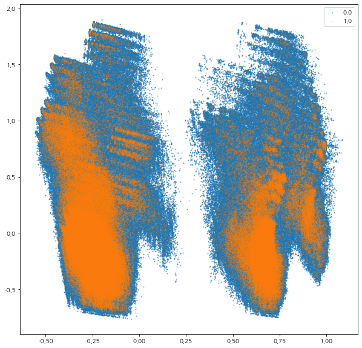

```python
k=3 #투명도 조절을 위해 정의
plt.figure(figsize = (10,10))
#plt.xlim(-11,15)
#plt.ylim(-7,40)
for i in sorted(y_train.unique()):
    tmp = pca_df.loc[pca_df["신청여부(타겟)"] == i] #해당하는 클러스터 번호일 때 그림을 그리고, for문 실행하며 위에 덧그림
    plt.scatter(tmp[0], tmp[1], s=1, alpha = 0.2*k)
    k-=2
plt.legend(sorted(y_train.unique()))
plt.show()
```

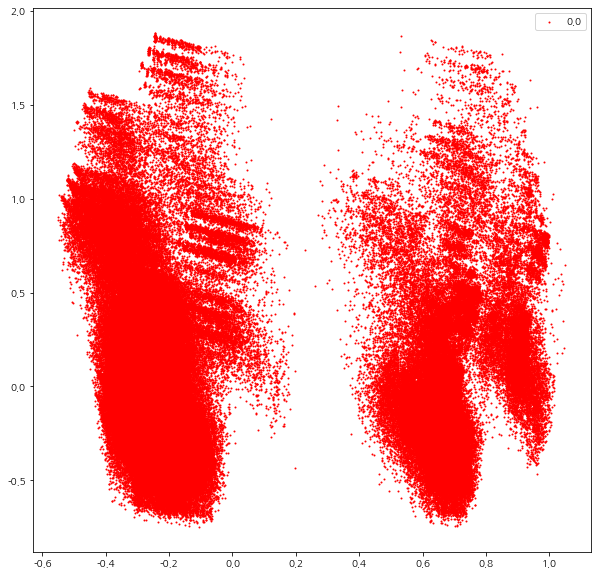

```python
tmp = pca_df.loc[pca_df["신청여부(타겟)"] == 1] #해당하는 클러스터 번호일 때 그림을 그리고, for문 실행하며 위에 덧그림
plt.figure(figsize = (10,10))
#plt.xlim(-11,15)
#plt.ylim(-7,40)
plt.scatter(tmp[0], tmp[1], color = 'r', s= 1)
plt.legend(sorted(y_train.unique()))
plt.show()
```

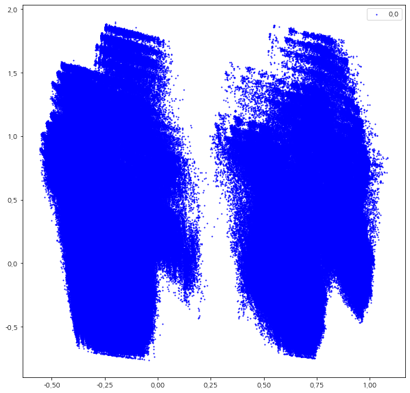

```python
tmp = pca_df.loc[pca_df["신청여부(타겟)"] == 0] #해당하는 클러스터 번호일 때 그림을 그리고, for문 실행하며 위에 덧그림
plt.figure(figsize = (10,10))
#plt.xlim(-11,15)
#plt.ylim(-7,40)
plt.scatter(tmp[0], tmp[1], color = 'b', s= 1)
plt.legend(sorted(y_train.unique()))
plt.show()
```

## lgbm

```python
lgbm_wrapper = LGBMClassifier(n_estimators=500, learning_rate=0.05, device = 'gpu', scale_pos_weight = 2)

# 문제는 imbalance data였다!

evals = [(X_tr, y_tr), (X_val, y_val)]
lgbm_wrapper.fit(X_tr, y_tr, early_stopping_rounds=50, eval_metric="logloss",
                 eval_set=evals, verbose=True)
preds =lgbm_wrapper.predict(X_test)
lgb_pred_proba = lgbm_wrapper.predict_proba(X_test)[:, 1]
```

```
[1]	training's binary_logloss: 0.196917	valid_1's binary_logloss: 0.197003
[2]	training's binary_logloss: 0.188909	valid_1's binary_logloss: 0.18904
[3]	training's binary_logloss: 0.183134	valid_1's binary_logloss: 0.183301
[4]	training's binary_logloss: 0.178629	valid_1's binary_logloss: 0.178837
[5]	training's binary_logloss: 0.175036	valid_1's binary_logloss: 0.175279
[6]	training's binary_logloss: 0.172024	valid_1's binary_logloss: 0.172291
[7]	training's binary_logloss: 0.169522	valid_1's binary_logloss: 0.169813
[8]	training's binary_logloss: 0.167418	valid_1's binary_logloss: 0.167732
[9]	training's binary_logloss: 0.165519	valid_1's binary_logloss: 0.16586
[10]	training's binary_logloss: 0.163954	valid_1's binary_logloss: 0.164314
[11]	training's binary_logloss: 0.162529	valid_1's binary_logloss: 0.162914
[12]	training's binary_logloss: 0.161292	valid_1's binary_logloss: 0.161696
[13]	training's binary_logloss: 0.160218	valid_1's binary_logloss: 0.160642
[14]	training's binary_logloss: 0.159255	valid_1's binary_logloss: 0.159696
[15]	training's binary_logloss: 0.158375	valid_1's binary_logloss: 0.15883
[16]	training's binary_logloss: 0.157611	valid_1's binary_logloss: 0.158079
[17]	training's binary_logloss: 0.156928	valid_1's binary_logloss: 0.157408
[18]	training's binary_logloss: 0.156324	valid_1's binary_logloss: 0.156809
[19]	training's binary_logloss: 0.155767	valid_1's binary_logloss: 0.156266
[20]	training's binary_logloss: 0.155262	valid_1's binary_logloss: 0.155773
[21]	training's binary_logloss: 0.154784	valid_1's binary_logloss: 0.15531
[22]	training's binary_logloss: 0.154395	valid_1's binary_logloss: 0.15493
[23]	training's binary_logloss: 0.154026	valid_1's binary_logloss: 0.154574
[24]	training's binary_logloss: 0.153699	valid_1's binary_logloss: 0.154259
[25]	training's binary_logloss: 0.153363	valid_1's binary_logloss: 0.15394
[26]	training's binary_logloss: 0.153053	valid_1's binary_logloss: 0.153636
[27]	training's binary_logloss: 0.152798	valid_1's binary_logloss: 0.153386
[28]	training's binary_logloss: 0.15255	valid_1's binary_logloss: 0.153147
[29]	training's binary_logloss: 0.152291	valid_1's binary_logloss: 0.152899
[30]	training's binary_logloss: 0.15208	valid_1's binary_logloss: 0.152698
[31]	training's binary_logloss: 0.151874	valid_1's binary_logloss: 0.152503
[32]	training's binary_logloss: 0.151695	valid_1's binary_logloss: 0.152329
[33]	training's binary_logloss: 0.151507	valid_1's binary_logloss: 0.152153
[34]	training's binary_logloss: 0.151353	valid_1's binary_logloss: 0.152005
[35]	training's binary_logloss: 0.151193	valid_1's binary_logloss: 0.151853
[36]	training's binary_logloss: 0.151036	valid_1's binary_logloss: 0.151706
[37]	training's binary_logloss: 0.150897	valid_1's binary_logloss: 0.151573
[38]	training's binary_logloss: 0.150789	valid_1's binary_logloss: 0.151471
[39]	training's binary_logloss: 0.150657	valid_1's binary_logloss: 0.151345
[40]	training's binary_logloss: 0.150542	valid_1's binary_logloss: 0.151238
```

[output cut: 445 more lines]

```
[486]	training's binary_logloss: 0.143022	valid_1's binary_logloss: 0.144539
[487]	training's binary_logloss: 0.143017	valid_1's binary_logloss: 0.144534
[488]	training's binary_logloss: 0.143013	valid_1's binary_logloss: 0.14453
[489]	training's binary_logloss: 0.143006	valid_1's binary_logloss: 0.144525
[490]	training's binary_logloss: 0.143	valid_1's binary_logloss: 0.144524
[491]	training's binary_logloss: 0.143001	valid_1's binary_logloss: 0.144528
[492]	training's binary_logloss: 0.142998	valid_1's binary_logloss: 0.144527
[493]	training's binary_logloss: 0.142996	valid_1's binary_logloss: 0.144525
[494]	training's binary_logloss: 0.142992	valid_1's binary_logloss: 0.144522
[495]	training's binary_logloss: 0.14299	valid_1's binary_logloss: 0.144521
[496]	training's binary_logloss: 0.142984	valid_1's binary_logloss: 0.144516
[497]	training's binary_logloss: 0.14298	valid_1's binary_logloss: 0.144514
[498]	training's binary_logloss: 0.142977	valid_1's binary_logloss: 0.144513
[499]	training's binary_logloss: 0.142972	valid_1's binary_logloss: 0.144511
[500]	training's binary_logloss: 0.142968	valid_1's binary_logloss: 0.144508
```

```python
get_clf_eval(y_test, preds, lgb_pred_proba)
```

```
오차 행렬
[[1889685   52251]
 [  65739   45203]]
정확도: 0.9425, 정밀도: 0.4638, 재현율: 0.4074,    F1: 0.4338, AUC:0.9199
```

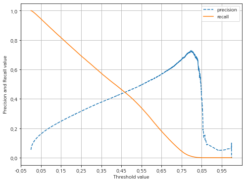

```python
precision_recall_curve_plot(y_test, lgb_pred_proba)
```

```python
thresholds = [0.41,0.43, 0.45, 0.47]
pred_probas = lgb_pred_proba.reshape(-1,1)
for thres_val in thresholds:
    binarizer = Binarizer(threshold = thres_val).fit(pred_probas)
    new_pred = binarizer.transform(pred_probas)
    get_clf_eval(y_test , new_pred, pred_probas)
    print(classification_report(new_pred, y_test))
```

```
오차 행렬
[[1861425   80511]
 [  54629   56313]]
정확도: 0.9342, 정밀도: 0.4116, 재현율: 0.5076,    F1: 0.4546, AUC:0.9199
              precision    recall  f1-score   support

         0.0       0.96      0.97      0.96   1916054
         1.0       0.51      0.41      0.45    136824

    accuracy                           0.93   2052878
   macro avg       0.73      0.69      0.71   2052878
weighted avg       0.93      0.93      0.93   2052878

오차 행렬
[[1868337   73599]
 [  56996   53946]]
정확도: 0.9364, 정밀도: 0.4230, 재현율: 0.4863,    F1: 0.4524, AUC:0.9199
              precision    recall  f1-score   support

         0.0       0.96      0.97      0.97   1925333
         1.0       0.49      0.42      0.45    127545

    accuracy                           0.94   2052878
   macro avg       0.72      0.70      0.71   2052878
weighted avg       0.93      0.94      0.93   2052878

오차 행렬
[[1874830   67106]
 [  59451   51491]]
정확도: 0.9384, 정밀도: 0.4342, 재현율: 0.4641,    F1: 0.4486, AUC:0.9199
              precision    recall  f1-score   support

         0.0       0.97      0.97      0.97   1934281
         1.0       0.46      0.43      0.45    118597

    accuracy                           0.94   2052878
   macro avg       0.71      0.70      0.71   2052878
weighted avg       0.94      0.94      0.94   2052878

오차 행렬
[[1880984   60952]
 [  61874   49068]]
정확도: 0.9402, 정밀도: 0.4460, 재현율: 0.4423,    F1: 0.4441, AUC:0.9199
              precision    recall  f1-score   support

         0.0       0.97      0.97      0.97   1942858
         1.0       0.44      0.45      0.44    110020

    accuracy                           0.94   2052878
   macro avg       0.71      0.71      0.71   2052878
weighted avg       0.94      0.94      0.94   2052878
```

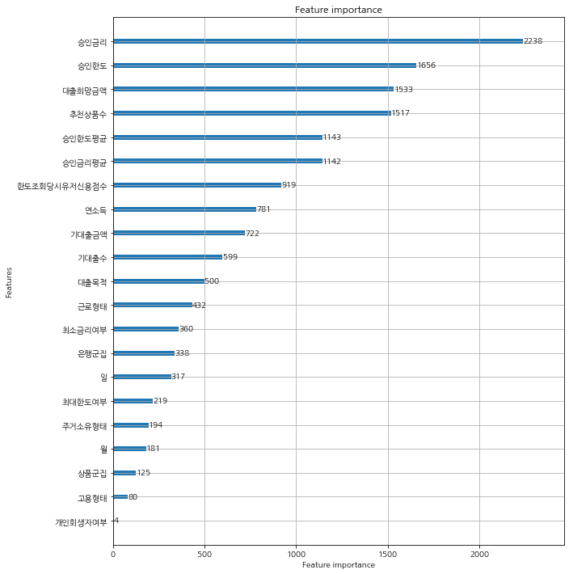

```python
from lightgbm import plot_importance
fig, ax = plt.subplots(figsize=(10, 12))
plot_importance(lgbm_wrapper, ax=ax)
```

```python
joblib.dump(lgbm_wrapper, './lgbm_fin2')
```

```
['./lgbm_fin2']
```

## XGBoost

```python
xgb_wrapper = XGBClassifier(n_estimators=500, learning_rate=0.05, tree_method ='gpu_hist',
          predictor = 'gpu_predictor', scale_pos_weight = 2)
evals = [(X_tr, y_tr), (X_val, y_val)]


xgb_wrapper.fit(X_tr, y_tr, early_stopping_rounds=50, eval_metric="logloss",
                eval_set=evals, verbose=True)


xgb_preds = xgb_wrapper.predict(X_test)
xgb_pred_proba = xgb_wrapper.predict_proba(X_test)[:, 1]
```

```python
print(classification_report(xgb_preds, y_test))
```

```
              precision    recall  f1-score   support

           0       0.97      0.97      0.97   1955799
           1       0.41      0.47      0.43     97079

    accuracy                           0.94   2052878
   macro avg       0.69      0.72      0.70   2052878
weighted avg       0.95      0.94      0.94   2052878
```

```python
get_clf_eval(y_test, xgb_preds, xgb_pred_proba)
```

```
오차 행렬
[[1890030   51906]
 [  65769   45173]]
정확도: 0.9427, 정밀도: 0.4653, 재현율: 0.4072,    F1: 0.4343, AUC:0.9201
```

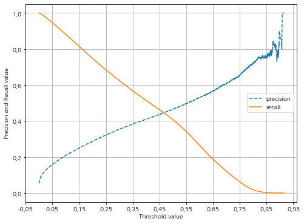

```python
precision_recall_curve_plot(y_test, xgb_pred_proba)
```

```python
thresholds = [0.42,0.45,0.48]
pred_probas = xgb_pred_proba.reshape(-1,1)
for thres_val in thresholds:
    binarizer = Binarizer(threshold = thres_val).fit(pred_probas)
    new_pred = binarizer.transform(pred_probas)
    get_clf_eval(y_test , new_pred, pred_probas)
    print(classification_report(new_pred, y_test))
```

```
오차 행렬
[[1866464   75472]
 [  56172   54770]]
정확도: 0.9359, 정밀도: 0.4205, 재현율: 0.4937,    F1: 0.4542, AUC:0.9201
              precision    recall  f1-score   support

         0.0       0.96      0.97      0.97   1922636
         1.0       0.49      0.42      0.45    130242

    accuracy                           0.94   2052878
   macro avg       0.73      0.70      0.71   2052878
weighted avg       0.93      0.94      0.93   2052878

오차 행렬
[[1875673   66263]
 [  59546   51396]]
정확도: 0.9387, 정밀도: 0.4368, 재현율: 0.4633,    F1: 0.4497, AUC:0.9201
              precision    recall  f1-score   support

         0.0       0.97      0.97      0.97   1935219
         1.0       0.46      0.44      0.45    117659

    accuracy                           0.94   2052878
   macro avg       0.71      0.70      0.71   2052878
weighted avg       0.94      0.94      0.94   2052878

오차 행렬
[[1884441   57495]
 [  63133   47809]]
정확도: 0.9412, 정밀도: 0.4540, 재현율: 0.4309,    F1: 0.4422, AUC:0.9201
              precision    recall  f1-score   support

         0.0       0.97      0.97      0.97   1947574
         1.0       0.43      0.45      0.44    105304

    accuracy                           0.94   2052878
   macro avg       0.70      0.71      0.71   2052878
weighted avg       0.94      0.94      0.94   2052878
```

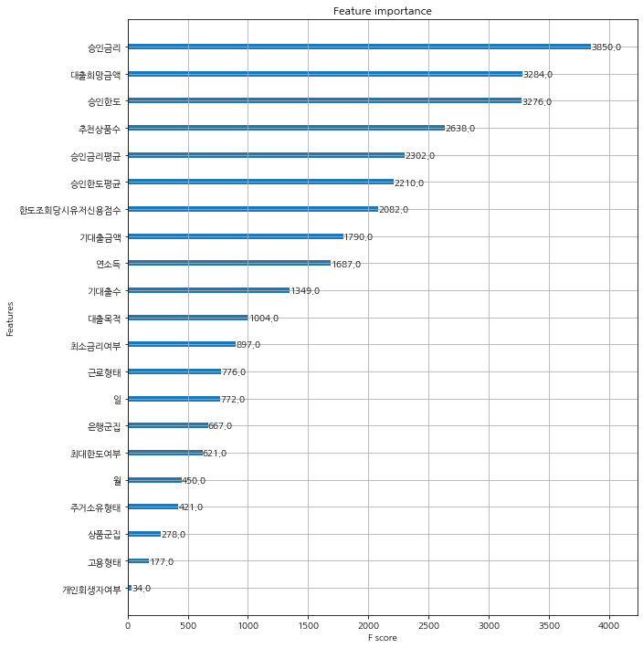

```python
from xgboost import plot_importance
fig, ax = plt.subplots(figsize=(10, 12))
# 사이킷런 래퍼 클래스를 입력해도 무방.
plot_importance(xgb_wrapper, ax=ax)
```

```python
joblib.dump(xgb_wrapper, './xgb_fin2')
```

```
['./xgb_fin2']
```

## Deeplearning

```python
import tensorflow as tf
from tensorflow import keras
import os
import tempfile
```

```python
from keras.layers import BatchNormalization, Dropout
```

```python
colors = plt.rcParams['axes.prop_cycle'].by_key()['color']
```

## RandomUnderSampler

- 1:1 의 비율로 맞추기위해 삭제한 경우 성능이 크게 향상되진 않았다. Xgboost 보다는 안좋음.
- 다수: 소수 = 2:1로 비율을 맞춘 경우 성능이 나빠졌다.

```python
rus = RandomUnderSampler(random_state = 0, sampling_strategy = 0.5)
# sampling_strategy = (소수 집단 데이터수/ 다수 집단 데이터수)
```

```python
X_samp, y_samp = rus.fit_resample(X_train, y_train)
```

```python
y_samp.value_counts()
```

```
0.0    887538
1.0    443769
Name: 신청여부(타겟), dtype: int64
```

```python
x_pca = pca.transform(X_samp)
pca_df = pd.DataFrame(x_pca)
pca_df["신청여부(타겟)"] = y_samp
```

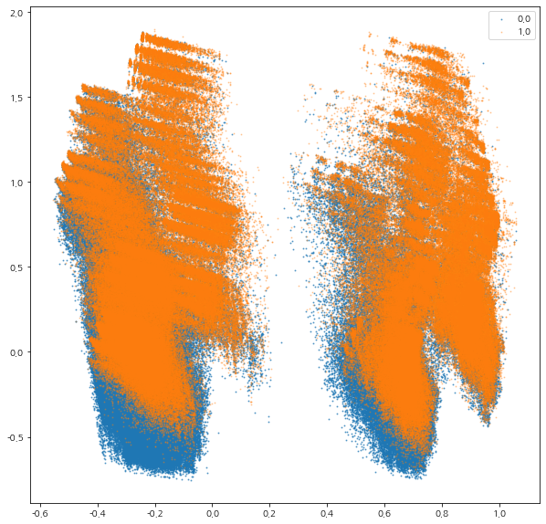

```python
k=2
plt.figure(figsize = (10,10))
#plt.xlim(-11,15)
#plt.ylim(-7,40)
for i in sorted(y_train.unique()):
    tmp = pca_df.loc[pca_df["신청여부(타겟)"] == i] #해당하는 클러스터 번호일 때 그림을 그리고, for문 실행하며 위에 덧그림
    plt.scatter(tmp[0], tmp[1], s=1, alpha = 0.3*k)
    k-=1
plt.legend(sorted(y_train.unique()))
plt.show()
```

## Edited Nearest Neighbours

- 컴퓨터 능력이 안된다...

```python
enn = EditedNearestNeighbours(kind_sel = 'all', n_neighbors = 5)
# 다수 클래스 중 가장 가까운 k 개의 데이터가 모두 다수 클래스가 아니면 다수 클래스 데이터 사라짐
```

## train_test_split 2

```python
X_tr, X_val, y_tr, y_val= train_test_split(X_samp, y_samp,
                                         test_size=0.1, random_state=156, stratify = y_samp )
```

```python
train_features = X_tr
train_labels = y_tr
val_features = X_val
val_labels = y_val
```

```python
X_val
```

|  | 월 | 일 | 한도조회당시유저신용점수 | 연소득 | 근로형태 | 고용형태 | 주거소유형태 | 대출희망금액 | 대출목적 | 개인회생자여부 | 기대출수 | 기대출금액 | 승인한도 | 승인금리 | 상품군집 | 은행군집 | 추천상품수 | 최소금리여부 | 승인금리평균 | 최대한도여부 | 승인한도평균 |
| --- | --- | --- | --- | --- | --- | --- | --- | --- | --- | --- | --- | --- | --- | --- | --- | --- | --- | --- | --- | --- | --- |
| 982420 | 0.333333 | 0.133333 | 0.598048 | 0.0019 | 0.000000 | 0.226112 | 0.609171 | 0.0010 | 0.535261 | 0.0 | 0.013100 | 0.004925 | 0.000048 | 0.270270 | 0.86632 | 0.076869 | 0.358974 | 1.0 | 0.563840 | 0.0 | 0.002156 |
| 1257013 | 0.666667 | 0.733333 | 0.577064 | 0.0020 | 0.000000 | 0.000000 | 1.000000 | 0.0003 | 1.000000 | 0.0 | 0.043668 | 0.007455 | 0.000039 | 0.924324 | 0.00000 | 0.005130 | 0.051282 | 0.0 | 0.790270 | 0.0 | 0.002118 |
| 257344 | 0.000000 | 0.966667 | 0.923303 | 0.0035 | 0.693735 | 1.000000 | 0.609171 | 0.0044 | 0.149011 | 0.0 | 0.000000 | 0.000000 | 0.000022 | 0.756757 | 0.00000 | 0.005130 | 0.538462 | 0.0 | 0.525707 | 0.0 | 0.005487 |
| 1273807 | 0.000000 | 0.433333 | 0.661001 | 0.0028 | 0.000000 | 0.000000 | 0.609171 | 0.0030 | 0.535261 | 0.0 | 0.017467 | 0.004393 | 0.000013 | 0.616216 | 0.86632 | 0.076869 | 0.217949 | 0.0 | 0.662162 | 0.0 | 0.003219 |
| 33738 | 0.000000 | 0.966667 | 0.870843 | 0.0035 | 0.000000 | 0.000000 | 0.609171 | 0.0010 | 1.000000 | 0.0 | 0.000000 | 0.000000 | 0.000048 | 0.281081 | 0.86632 | 0.005130 | 0.820513 | 0.0 | 0.566985 | 0.0 | 0.004441 |
| ... | ... | ... | ... | ... | ... | ... | ... | ... | ... | ... | ... | ... | ... | ... | ... | ... | ... | ... | ... | ... | ... |
| 666397 | 0.333333 | 0.666667 | 0.849858 | 0.0030 | 1.000000 | 1.000000 | 0.609171 | 0.0010 | 1.000000 | 0.0 | 0.004367 | 0.000000 | 0.000130 | 0.875676 | 0.00000 | 0.005130 | 0.192308 | 0.0 | 0.715878 | 0.0 | 0.004046 |
| 644839 | 0.000000 | 0.766667 | 0.524604 | 0.0030 | 0.000000 | 0.000000 | 1.000000 | 0.0010 | 1.000000 | 0.0 | 0.048035 | 0.010650 | 0.000035 | 0.708108 | 0.00000 | 0.005130 | 0.051282 | 0.0 | 0.801081 | 0.0 | 0.001438 |
| 966867 | 0.666667 | 0.233333 | 0.587556 | 0.0012 | 1.000000 | 1.000000 | 1.000000 | 0.0002 | 1.000000 | 0.0 | 0.030568 | 0.003195 | 0.000017 | 0.800000 | 0.00000 | 0.005130 | 0.000000 | 1.0 | 0.800000 | 1.0 | 0.000799 |
| 816775 | 0.000000 | 0.100000 | 0.849858 | 0.0046 | 0.000000 | 0.000000 | 1.000000 | 0.0050 | 1.000000 | 0.0 | 0.043668 | 0.013845 | 0.000026 | 0.545946 | 0.00000 | 0.005130 | 0.435897 | 0.0 | 0.684479 | 0.0 | 0.002032 |
| 808242 | 0.666667 | 0.833333 | 0.629525 | 0.0012 | 0.523755 | 0.000000 | 0.135352 | 0.0010 | 0.752258 | 0.0 | 0.017467 | 0.028488 | 0.000074 | 0.994595 | 0.00000 | 0.005130 | 0.076923 | 0.0 | 0.757529 | 0.0 | 0.003653 |

133131 rows × 21 columns

**평가지표 정의**

```python
# neg, pos = np.bincount(y_tr)
# total = neg + pos
# print('Examples:\n    Total: {}\n    Positive: {} ({:.2f}% of total)\n'.format(
#     total, pos, 100 * pos / total))

# initial_bias = np.log([pos/neg])
# initial_bias

METRICS = [
#      keras.metrics.TruePositives(name='tp'),
#      keras.metrics.FalsePositives(name='fp'),
#      keras.metrics.TrueNegatives(name='tn'),
#      keras.metrics.FalseNegatives(name='fn'),
      keras.metrics.BinaryAccuracy(name='accuracy'),
      keras.metrics.Precision(name='precision'),
      keras.metrics.Recall(name='recall'),
      keras.metrics.AUC(name='auc'),
      keras.metrics.AUC(name='prc', curve='PR'), # precision-recall curve
]
```

```python
def make_model2(metrics=METRICS):
    input = tf.keras.layers.Input(shape=(21,))
    net = tf.keras.layers.Dense(units=42)(input)
    net = tf.keras.layers.BatchNormalization()(net)
    net = tf.keras.layers.Activation(activation='relu')(net)
    net = tf.keras.layers.Dense(units=42)(net)
    net = tf.keras.layers.BatchNormalization()(net)
    net = tf.keras.layers.Activation(activation='relu')(net)
    net = tf.keras.layers.Dense(units=1, activation='sigmoid')(net)

    model = tf.keras.models.Model(input, net)

    model.compile(
      optimizer=keras.optimizers.Adam(learning_rate=0.001),
      loss=keras.losses.BinaryCrossentropy(),
      metrics=metrics)

    return model
```

```python
def make_model(metrics=METRICS, output_bias=None):
  if output_bias is not None:
    output_bias = tf.keras.initializers.Constant(output_bias)
  model = keras.Sequential([
      keras.layers.Dense(
          21, activation='relu',
          input_shape=(train_features.shape[-1],)),
      keras.layers.Dropout((0.5)),

      keras.layers.Dense(
          42, activation='relu',
          input_shape=(train_features.shape[-1],)),
      keras.layers.Dropout((0.5)),

      keras.layers.Dense(
          42, activation='relu',
          input_shape=(train_features.shape[-1],)),
      keras.layers.Dropout((0.5)),

      keras.layers.Dense(1, activation='sigmoid',
                         bias_initializer=output_bias),
  ])

  model.compile(
      optimizer=keras.optimizers.Adam(learning_rate=0.001),
      loss=keras.losses.BinaryCrossentropy(),
      metrics=metrics)

  return model

def plot_metrics(history):
  metrics = ['loss', 'auc', 'precision', 'recall']
  for n, metric in enumerate(metrics):
    name = metric.replace("_"," ").capitalize()
    plt.subplot(2,2,n+1)
    plt.plot(history.epoch, history.history[metric], color=colors[0], label='Train')
    plt.plot(history.epoch, history.history['val_'+metric],
             color=colors[0], linestyle="--", label='Val')
    plt.xlabel('Epoch')
    plt.ylabel(name)
    if metric == 'loss':
      plt.ylim([0, plt.ylim()[1]])
    elif metric == 'auc':
      plt.ylim([0.8,1])
    else:
      plt.ylim([0,1])

    plt.legend()
```

```python
model = make_model(METRICS)
model.summary()
```

```
Model: "sequential_1"
_________________________________________________________________
 Layer (type)                Output Shape              Param #
=================================================================
 dense_7 (Dense)             (None, 21)                462

 dropout_3 (Dropout)         (None, 21)                0

 dense_8 (Dense)             (None, 42)                924

 dropout_4 (Dropout)         (None, 42)                0

 dense_9 (Dense)             (None, 42)                1806

 dropout_5 (Dropout)         (None, 42)                0

 dense_10 (Dense)            (None, 1)                 43

=================================================================
Total params: 3,235
Trainable params: 3,235
Non-trainable params: 0
_________________________________________________________________
```

```python
model2 = make_model2(METRICS)
model2.summary()
```

```
Model: "model_1"
_________________________________________________________________
 Layer (type)                Output Shape              Param #
=================================================================
 input_2 (InputLayer)        [(None, 21)]              0

 dense_11 (Dense)            (None, 42)                924

 batch_normalization_2 (Batc  (None, 42)               168
 hNormalization)

 activation_2 (Activation)   (None, 42)                0

 dense_12 (Dense)            (None, 42)                1806

 batch_normalization_3 (Batc  (None, 42)               168
 hNormalization)

 activation_3 (Activation)   (None, 42)                0

 dense_13 (Dense)            (None, 1)                 43

=================================================================
Total params: 3,109
Trainable params: 2,941
Non-trainable params: 168
_________________________________________________________________
```

```python
EPOCHS = 50
BATCH_SIZE = 10000

early_stopping = tf.keras.callbacks.EarlyStopping(
    monitor='val_auc',
    verbose=10,
    patience=10,
    mode='max',
    restore_best_weights=True)
```

## weighted deep learning

```python
count = y_train.value_counts().values
```

```python
weight_for_0 = (1 / count[0]) * (sum(count)/2.0)
weight_for_1 = (1/ count[1])*(sum(count)/2.0)
```

```python
print('Weight for class 0: {:.2f}'.format(weight_for_0))
print('Weight for class 1: {:.2f}'.format(weight_for_1))
```

```
Weight for class 0: 0.53
Weight for class 1: 9.25
```

- 이렇게 설정하면 1이라고 예측하는 경우가 너무 많아진다.

```python
weight_for_1 = 5.3
```

```python
class_weight = {0: weight_for_0, 1: weight_for_1}

print('Weight for class 0: {:.2f}'.format(weight_for_0))
print('Weight for class 1: {:.2f}'.format(weight_for_1))
```

```
Weight for class 0: 0.53
Weight for class 1: 5.30
```

- 1의 weight를 낮추어도 precision recall curve가 이상하다..

```python
weighted_history = model2.fit(
    train_features,
    train_labels,
    batch_size=BATCH_SIZE,
    epochs=EPOCHS,
    callbacks=[early_stopping],
    validation_data=(val_features, val_labels),
    class_weight = class_weight
)
```

```
Epoch 11: early stopping
```

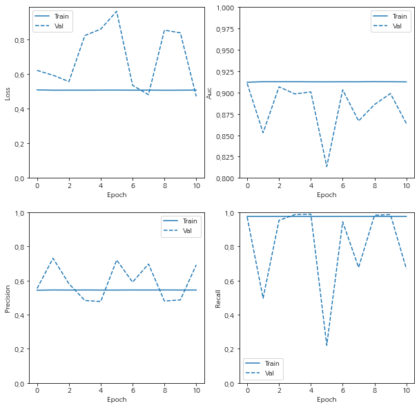

```python
plt.figure(figsize = (10,10))
plot_metrics(weighted_history)
```

```python
pred = model2.predict(X_test)
```

```python
y_new = np.array(y_test).reshape(-1,1)
```

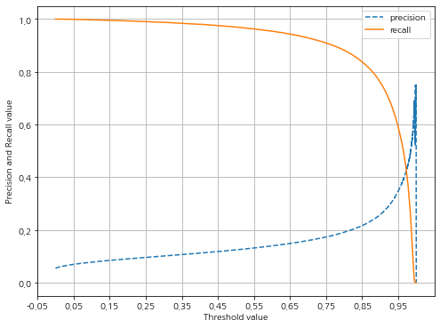

```python
precision_recall_curve_plot(y_new, pred)
```

```python
pd.Series(pred.reshape(-1)).describe()
```

```
count    2.052878e+06
mean     4.250068e-01
std      3.600463e-01
min      1.639821e-06
25%      6.384812e-02
50%      3.481282e-01
75%      7.987711e-01
max      9.999172e-01
dtype: float64
```

```python
thresholds = [0.5, 0.95]
pred_probas = pred
for thres_val in thresholds:
    binarizer = Binarizer(threshold = thres_val).fit(pred_probas)
    new_pred = binarizer.transform(pred_probas)
    get_clf_eval(y_test , new_pred, pred_probas)
    print(classification_report(new_pred, y_test))
```

```
오차 행렬
[[1185478  756458]
 [   3366  107576]]
정확도: 0.6299, 정밀도: 0.1245, 재현율: 0.9697,    F1: 0.2207, AUC:0.9112
              precision    recall  f1-score   support

         0.0       0.61      1.00      0.76   1188844
         1.0       0.97      0.12      0.22    864034

    accuracy                           0.63   2052878
   macro avg       0.79      0.56      0.49   2052878
weighted avg       0.76      0.63      0.53   2052878

오차 행렬
[[1819241  122695]
 [  45594   65348]]
정확도: 0.9180, 정밀도: 0.3475, 재현율: 0.5890,    F1: 0.4371, AUC:0.9112
              precision    recall  f1-score   support

         0.0       0.94      0.98      0.96   1864835
         1.0       0.59      0.35      0.44    188043

    accuracy                           0.92   2052878
   macro avg       0.76      0.66      0.70   2052878
weighted avg       0.90      0.92      0.91   2052878
```

## deep_learning model 1

```python
EPOCHS = 50
BATCH_SIZE = 1000

early_stopping = tf.keras.callbacks.EarlyStopping(
    monitor='val_auc',
    verbose=1,
    patience=10,
    mode='max',
    restore_best_weights=True)
```

```python
baseline_history = model.fit(
    train_features,
    train_labels,
    batch_size=BATCH_SIZE,
    epochs=EPOCHS,
    callbacks=[early_stopping],
    validation_data=(val_features, val_labels))
```

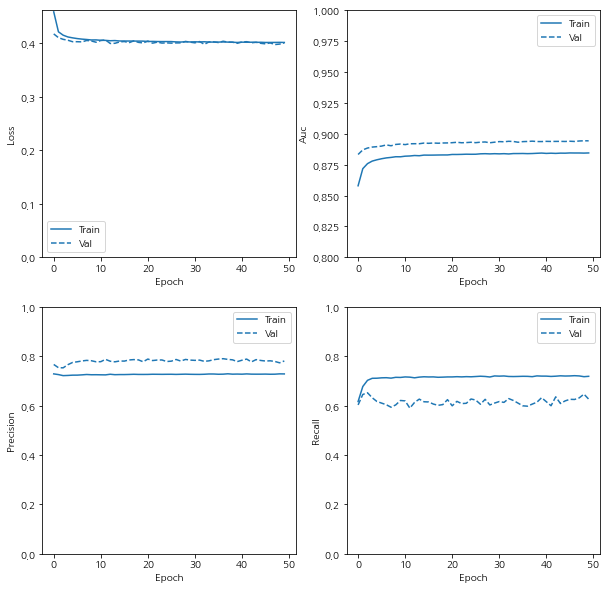

```python
plt.figure(figsize = (10,10))
plot_metrics(baseline_history)
```

```python
pred = model.predict(X_test)
```

```python
y_new = np.array(y_test).reshape(-1,1)
```

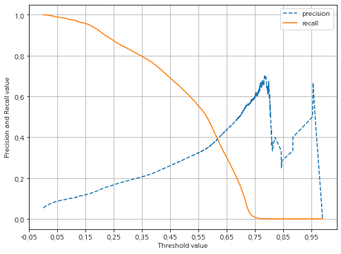

```python
precision_recall_curve_plot(y_new, pred)
```

```python
thresholds = [0.5, 0.57, 0.60, 0.63]
pred_probas = pred
for thres_val in thresholds:
    binarizer = Binarizer(threshold = thres_val).fit(pred_probas)
    new_pred = binarizer.transform(pred_probas)
    get_clf_eval(y_test , new_pred, pred_probas)
    print(classification_report(new_pred, y_test))
```

```
오차 행렬
[[1773565  168371]
 [  41382   69560]]
정확도: 0.8978, 정밀도: 0.2924, 재현율: 0.6270,    F1: 0.3988, AUC:0.8943
              precision    recall  f1-score   support

         0.0       0.91      0.98      0.94   1814947
         1.0       0.63      0.29      0.40    237931

    accuracy                           0.90   2052878
   macro avg       0.77      0.63      0.67   2052878
weighted avg       0.88      0.90      0.88   2052878

오차 행렬
[[1829285  112651]
 [  53376   57566]]
정확도: 0.9191, 정밀도: 0.3382, 재현율: 0.5189,    F1: 0.4095, AUC:0.8943
              precision    recall  f1-score   support

         0.0       0.94      0.97      0.96   1882661
         1.0       0.52      0.34      0.41    170217

    accuracy                           0.92   2052878
   macro avg       0.73      0.65      0.68   2052878
weighted avg       0.91      0.92      0.91   2052878

오차 행렬
[[1857864   84072]
 [  61894   49048]]
정확도: 0.9289, 정밀도: 0.3684, 재현율: 0.4421,    F1: 0.4019, AUC:0.8943
              precision    recall  f1-score   support

         0.0       0.96      0.97      0.96   1919758
         1.0       0.44      0.37      0.40    133120

    accuracy                           0.93   2052878
   macro avg       0.70      0.67      0.68   2052878
weighted avg       0.92      0.93      0.93   2052878

오차 행렬
[[1885448   56488]
 [  71735   39207]]
정확도: 0.9375, 정밀도: 0.4097, 재현율: 0.3534,    F1: 0.3795, AUC:0.8943
              precision    recall  f1-score   support

         0.0       0.97      0.96      0.97   1957183
         1.0       0.35      0.41      0.38     95695

    accuracy                           0.94   2052878
   macro avg       0.66      0.69      0.67   2052878
weighted avg       0.94      0.94      0.94   2052878
```

- 딥러닝 모델 저장:https://minimin2.tistory.com/105

```python
from keras.models import load_model
```

```python
model.save('dropout_model')
```

```
INFO:tensorflow:Assets written to: dropout_model\assets
```

**생각보다 validation 의 값들은 좋다. 과연 사실일까..?**

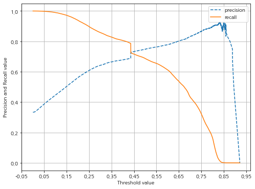

```python
val_pred = model.predict(X_val)
y_val = np.array(y_val).reshape(-1,1)
precision_recall_curve_plot(y_val, val_pred)
```

**꽤나 바람직한 precision recall curver가 나왔다..**

```python
thresholds = [0.45]
pred_probas = val_pred
for thres_val in thresholds:
    binarizer = Binarizer(threshold = thres_val).fit(pred_probas)
    new_pred = binarizer.transform(pred_probas)
    get_clf_eval(y_val , new_pred, pred_probas)
    print(classification_report(new_pred, y_val))
```

```
오차 행렬
[[77171 11583]
 [12598 31779]]
정확도: 0.8184, 정밀도: 0.7329, 재현율: 0.7161,    F1: 0.7244, AUC:0.8905
              precision    recall  f1-score   support

         0.0       0.87      0.86      0.86     89769
         1.0       0.72      0.73      0.72     43362

    accuracy                           0.82    133131
   macro avg       0.79      0.80      0.79    133131
weighted avg       0.82      0.82      0.82    133131
```

**validation에 대해서는 좋다...**

## deep_learning model2

```python
baseline_history = model2.fit(
    train_features,
    train_labels,
    batch_size=BATCH_SIZE,
    epochs=EPOCHS,
    callbacks=[early_stopping],
    validation_data=(val_features, val_labels))
```

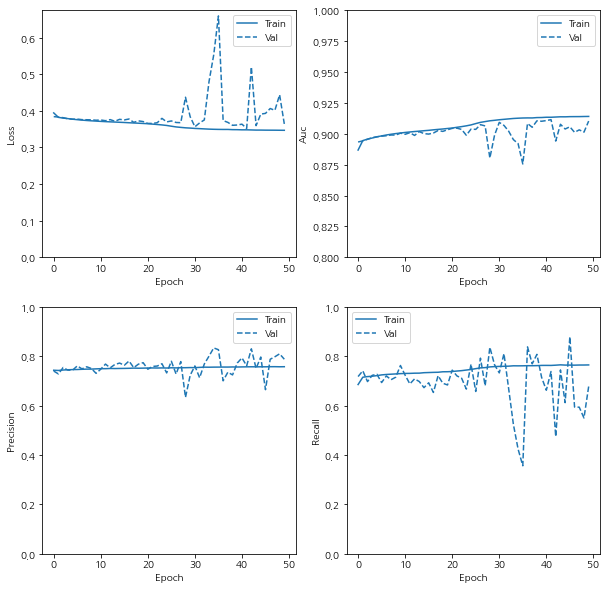

```python
plt.figure(figsize = (10,10))
plot_metrics(baseline_history)
```

```python
pred = model2.predict(X_test)
```

```python
y_new = np.array(y_test).reshape(-1,1)
```

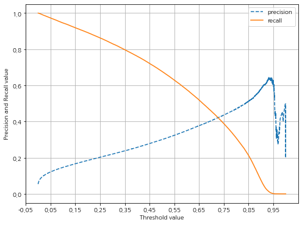

```python
precision_recall_curve_plot(y_new, pred)
```

```python
thresholds = [0.5,0.70,0.73,0.76]
pred_probas = pred
for thres_val in thresholds:
    binarizer = Binarizer(threshold = thres_val).fit(pred_probas)
    new_pred = binarizer.transform(pred_probas)
    get_clf_eval(y_test , new_pred, pred_probas)
    print(classification_report(new_pred, y_test))
```

```
오차 행렬
[[1766630  175306]
 [  35747   75195]]
정확도: 0.8972, 정밀도: 0.3002, 재현율: 0.6778,    F1: 0.4161, AUC:0.9111
              precision    recall  f1-score   support

         0.0       0.91      0.98      0.94   1802377
         1.0       0.68      0.30      0.42    250501

    accuracy                           0.90   2052878
   macro avg       0.79      0.64      0.68   2052878
weighted avg       0.88      0.90      0.88   2052878

오차 행렬
[[1867604   74332]
 [  60255   50687]]
정확도: 0.9344, 정밀도: 0.4054, 재현율: 0.4569,    F1: 0.4296, AUC:0.9111
              precision    recall  f1-score   support

         0.0       0.96      0.97      0.97   1927859
         1.0       0.46      0.41      0.43    125019

    accuracy                           0.93   2052878
   macro avg       0.71      0.69      0.70   2052878
weighted avg       0.93      0.93      0.93   2052878

오차 행렬
[[1878917   63019]
 [  64677   46265]]
정확도: 0.9378, 정밀도: 0.4233, 재현율: 0.4170,    F1: 0.4202, AUC:0.9111
              precision    recall  f1-score   support

         0.0       0.97      0.97      0.97   1943594
         1.0       0.42      0.42      0.42    109284

    accuracy                           0.94   2052878
   macro avg       0.69      0.70      0.69   2052878
weighted avg       0.94      0.94      0.94   2052878

오차 행렬
[[1889694   52242]
 [  69459   41483]]
정확도: 0.9407, 정밀도: 0.4426, 재현율: 0.3739,    F1: 0.4054, AUC:0.9111
              precision    recall  f1-score   support

         0.0       0.97      0.96      0.97   1959153
         1.0       0.37      0.44      0.41     93725

    accuracy                           0.94   2052878
   macro avg       0.67      0.70      0.69   2052878
weighted avg       0.95      0.94      0.94   2052878
```

```python
model2.save('./batchnormal_model')
```

```
INFO:tensorflow:Assets written to: ./batchnormal_model\assets
```